# Zomato_Restaurant

|  | **Exploratory Data Analysis** |
| --- | --- |

## Problem Statement

The zomato exploratory data analysis is for the foodies to find the best restaurants, value for money restaurants in their locality. It also helps to find their required cuisines in their locality.

## Data Definition

**res_id**: The code given to a restaurant (Categorical)

**name**: Name of the restaurant (Categorical)

**establishment**: Represents the type of establishment (Categorical)

**url**: The website of the restaurant (Categorical)

**address**: The address of the restaurant (Categorical)

**city**: City in which the restaurant located (Categorical)

**city_id**: The code given to a city (Categorical)

**locality**: Locality of the restaurant (Categorical)

**latitude**: Latitude of the restaurant (Categorical)

**longitude**: Longitude of the restaurant (Categorical)

**zipcode**: Zipcode of the city in which the restaurant located (Categorical)

**country_id**: Country code in which the restaurant located (Categorical)

**locality_verbose**: Locality along with the city in which the restaurant located (Categorical)

**cuisines**: The cuisines a restaurant serves (Categorical)

**timings**: The working hours of a restaurant (Categorical)

**average_cost_for_two**: The average amount expected for 2 people (Numerical)

**price_range**: The categories for average cost (Categories - 1,2,3,4) (Categorical)

**currency**: The currency in which a customer pays (Categorical)

**highlights**: The facilities of the restaurant (Categorical)

**aggregate_rating**: The overall rating a restaurant has got (Numerical)

**rating_text**: Categorized ratings (Categorical)

**votes**: Number of votes received by the restaurant from customers (Numerical)

**photo_count**: The number of photos of a restaurant (Numerical)

**opentable_support**: Restaurant reservation from Opentable (Categorical)

**delivery**: The restaurant deliver an order or not (Categorical)

**takeaway**: The restaurant allows a 'takeaway' of an order or not (Categorical)

1. **Import Libraries**
2. **Set Options**
3. **Read Data**
4. **Understand and Prepare the Data**
5. **Understand the variables**
6. **Check for Missing Values**
7. **Study Correlation**
8. **Detect Outliers**
9. **Create a new variable 'region'**
10. **Some more analysis**

## 1. Import Libraries

|  | **Import the required libraries and functions** |
| --- | --- |

```python
import pandas as pd
import numpy as np
```

## 2. Set Options

|  | Make necessary changes to : Set the working directory |
| --- | --- |

```python
!type pip
!type python
```

```
The system cannot find the file specified.
The system cannot find the file specified.
```

## 3. Read Data

```python
df=pd.read_csv('ZomatoRestaurantsIndia.csv')
```

## 4. Understand and Prepare the Data

A well-prepared data proves beneficial for analysis as it limits errors and inaccuracies that can occur during analysis. The processed data is more accessible to users.  
Data understanding is the process of getting familiar with the data, to identify data type, to discover first insights into the data, or to detect interesting subsets to form hypotheses about hidden information. Whereas, data preparation is the process of cleaning and transforming raw data before analysis. It is an important step before processing and often involves reformatting data, making corrections to data.  
Data preparation is often a lengthy process, but it is essential as a prerequisite to put data in context to get insights and eliminate bias resulting from poor data quality.

[figure not shown]

Analyze and prepare data:  
1. Check dimensions of the dataframe  
2. View the head of the data  
3. Note the redundant variables and drop them  
4. Check the data types. Refer to data definition to ensure your data types are correct. If data types are not as per business context, change the data types as per requirement  
5. Check for duplicates  
Note: It is an art to explore data and one will need more and more practice to gain expertise in this area

### ------------------------- *Provide the inference's from the output of every code executed.*----------------------------

**1. Check dimensions of the dataframe in terms of rows and columns**

```python
df.shape
```

```
(211944, 26)
```

**2. View the head of the data**

```python
df.head()
```

|  | res_id | name | establishment | url | address | city | city_id | locality | latitude | longitude | ... | price_range | currency | highlights | aggregate_rating | rating_text | votes | photo_count | opentable_support | delivery | takeaway |
| --- | --- | --- | --- | --- | --- | --- | --- | --- | --- | --- | --- | --- | --- | --- | --- | --- | --- | --- | --- | --- | --- |
| 0 | 3400299 | Bikanervala | Quick Bites | https://www.zomato.com/agra/bikanervala-khanda... | Kalyani Point, Near Tulsi Cinema, Bypass Road,... | Agra | 34 | Khandari | 27.211450 | 78.002381 | ... | 2 | Rs. | Lunch, Takeaway Available, Credit Card, Dinner... | 4.4 | Very Good | 814 | 154 | 0.0 | -1 | -1 |
| 1 | 3400005 | Mama Chicken Mama Franky House | Quick Bites | https://www.zomato.com/agra/mama-chicken-mama-... | Main Market, Sadar Bazaar, Agra Cantt, Agra | Agra | 34 | Agra Cantt | 27.160569 | 78.011583 | ... | 2 | Rs. | Delivery, No Alcohol Available, Dinner, Takeaw... | 4.4 | Very Good | 1203 | 161 | 0.0 | -1 | -1 |
| 2 | 3401013 | Bhagat Halwai | Quick Bites | https://www.zomato.com/agra/bhagat-halwai-2-sh... | 62/1, Near Easy Day, West Shivaji Nagar, Goalp... | Agra | 34 | Shahganj | 27.182938 | 77.979684 | ... | 1 | Rs. | No Alcohol Available, Dinner, Takeaway Availab... | 4.2 | Very Good | 801 | 107 | 0.0 | 1 | -1 |
| 3 | 3400290 | Bhagat Halwai | Quick Bites | https://www.zomato.com/agra/bhagat-halwai-civi... | Near Anjana Cinema, Nehru Nagar, Civil Lines, ... | Agra | 34 | Civil Lines | 27.205668 | 78.004799 | ... | 1 | Rs. | Takeaway Available, Credit Card, Lunch, Delive... | 4.3 | Very Good | 693 | 157 | 0.0 | 1 | -1 |
| 4 | 3401744 | The Salt Cafe Kitchen & Bar | Casual Dining | https://www.zomato.com/agra/the-salt-cafe-kitc... | 1C,3rd Floor, Fatehabad Road, Tajganj, Agra | Agra | 34 | Tajganj | 27.157709 | 78.052421 | ... | 3 | Rs. | Lunch, Serves Alcohol, Cash, Credit Card, Dinn... | 4.9 | Excellent | 470 | 291 | 0.0 | 1 | -1 |

5 rows × 26 columns

**3. Note the redundant variables and drop them**

```python
sorted (df.columns)
```

```
['address',
 'aggregate_rating',
 'average_cost_for_two',
 'city',
 'city_id',
 'country_id',
 'cuisines',
 'currency',
 'delivery',
 'establishment',
 'highlights',
 'latitude',
 'locality',
 'locality_verbose',
 'longitude',
 'name',
 'opentable_support',
 'photo_count',
 'price_range',
 'rating_text',
 'res_id',
 'takeaway',
 'timings',
 'url',
 'votes',
 'zipcode']
```

```python
df.columns
df = df.drop(['country_id','locality_verbose','currency','opentable_support'], axis=1)
```

```python
df.shape
```

```
(211944, 22)
```

**4. Check the data types. Refer to data definition to ensure your data types are correct. If data types are not as per business context, change the data types as per requirement**

```python
df
df.dtypes
```

```
res_id                    int64
name                     object
establishment            object
url                      object
address                  object
city                     object
city_id                   int64
locality                 object
latitude                float64
longitude               float64
zipcode                  object
cuisines                 object
timings                  object
average_cost_for_two      int64
price_range               int64
highlights               object
aggregate_rating        float64
rating_text              object
votes                     int64
photo_count               int64
delivery                  int64
takeaway                  int64
dtype: object
```

#### Change the incorrect data type

```python
df=df.astype('category')
#average_cost_for_two
#aggregate_rating
#photo_count
#votes
df.average_cost_for_two=df.average_cost_for_two.astype('int64')
df.votes=df.votes.astype('int64')
df.photo_count=df.photo_count.astype('int64')
df.aggregate_rating=df.aggregate_rating.astype('float64')
df.dtypes
```

```
res_id                  category
name                    category
establishment           category
url                     category
address                 category
city                    category
city_id                 category
locality                category
latitude                category
longitude               category
zipcode                 category
cuisines                category
timings                 category
average_cost_for_two       int64
price_range             category
highlights              category
aggregate_rating         float64
rating_text             category
votes                      int64
photo_count                int64
delivery                category
takeaway                category
dtype: object
```

**5. Check for Duplicates**

```python
#done on all the columns on the data
df_duplicate = df[df.duplicated()]
df_duplicate
```

|  | res_id | name | establishment | url | address | city | city_id | locality | latitude | longitude | ... | timings | average_cost_for_two | price_range | highlights | aggregate_rating | rating_text | votes | photo_count | delivery | takeaway |
| --- | --- | --- | --- | --- | --- | --- | --- | --- | --- | --- | --- | --- | --- | --- | --- | --- | --- | --- | --- | --- | --- |
| 101 | 3400059 | Peshawri - ITC Mughal | Fine Dining | https://www.zomato.com/agra/peshawri-itc-mugha... | ITC Mughal, Fatehabad Road, Tajganj, Agra | Agra | 34 | ITC Mughal, Tajganj | 27.161150 | 78.043993 | ... | 12:30 PM to 2:45 PM, 7 PM to 11:45 PM | 6000 | 4 | Lunch, Cash, Credit Card, Dinner, Debit Card, ... | 4.4 | Very Good | 353 | 154 | -1 | -1 |
| 116 | 3400060 | Taj Bano - ITC Mughal | Fine Dining | https://www.zomato.com/agra/taj-bano-itc-mugha... | ITC Mughal, Fatehabad Road, Tajganj, Agra | Agra | 34 | ITC Mughal, Tajganj | 27.161132 | 78.044022 | ... | 6 AM to 10:30 AM, 12:30 PM to 2:30 PM, 7 PM to... | 2500 | 4 | Credit Card, Lunch, Cash, Debit Card, Dinner, ... | 4.3 | Very Good | 96 | 205 | -1 | -1 |
| 140 | 3400017 | Pinch Of Spice | Casual Dining | https://www.zomato.com/agra/pinch-of-spice-civ... | 23/453, Opposite Sanjay Cinema, Wazipura Road,... | Agra | 34 | Civil Lines | 27.201735 | 78.007625 | ... | 12 Noon to 4 PM, 7 PM to 11:30 PM | 1600 | 4 | Lunch, Delivery, Credit Card, Dinner, Cash, Ta... | 4.6 | Excellent | 915 | 105 | 1 | -1 |
| 141 | 3400018 | Pinch Of Spice | Casual Dining | https://www.zomato.com/agra/pinch-of-spice-taj... | 1076/2, Fatehabad Road, Tajganj, Agra | Agra | 34 | Tajganj | 27.159649 | 78.043304 | ... | 12 Noon to 11:30 PM (Mon-Sun) | 1600 | 4 | Delivery, Dinner, Cash, Credit Card, Debit Car... | 4.6 | Excellent | 965 | 690 | 1 | -1 |
| 142 | 3400850 | Urban Deck | Casual Dining | https://www.zomato.com/agra/urban-deck-2-civil... | 5th Floor, The P L Palace Hotel, MG Road, Sanj... | Agra | 34 | Civil Lines | 27.199573 | 78.003699 | ... | 1PM to 12Midnight (Mon-Sun) | 1600 | 4 | Dinner, Cash, Debit Card, Takeaway Available, ... | 4.3 | Very Good | 672 | 192 | 1 | -1 |
| ... | ... | ... | ... | ... | ... | ... | ... | ... | ... | ... | ... | ... | ... | ... | ... | ... | ... | ... | ... | ... | ... |
| 211937 | 18855810 | Biryani aur Baatein | Casual Dining | https://www.zomato.com/vadodara/biryani-aur-ba... | Shop 14, Atlantis K-10, A Wing, Genda Circle R... | Vadodara | 32 | Alkapuri | 22.317746 | 73.168043 | ... | 11:30am – 3:30pm, 7:30pm – 1am (Mon-Sun) | 500 | 2 | Dinner, Cash, Takeaway Available, Debit Card, ... | 4.1 | Very Good | 154 | 96 | -1 | -1 |
| 211938 | 18662583 | Wok On Fire | Casual Dining | https://www.zomato.com/vadodara/wok-on-fire-fa... | Ground Floor 1, Rossette Building, Opposite Se... | Vadodara | 32 | Fatehgunj | 22.323357 | 73.187461 | ... | 11 AM to 11 PM | 1000 | 3 | Dinner, Cash, Debit Card, Lunch, Takeaway Avai... | 4.0 | Very Good | 301 | 126 | 1 | -1 |
| 211939 | 3202251 | Kali Mirch Cafe And Restaurant | Casual Dining | https://www.zomato.com/vadodara/kali-mirch-caf... | Manu Smriti Complex, Near Navrachna School, GI... | Vadodara | 32 | Fatehgunj | 22.336931 | 73.192356 | ... | 11am – 3pm, 7pm – 11:30pm (Mon-Sun) | 600 | 2 | Dinner, Cash, Lunch, Delivery, Indoor Seating,... | 4.1 | Very Good | 243 | 40 | -1 | -1 |
| 211941 | 18984164 | The Grand Thakar | Casual Dining | https://www.zomato.com/vadodara/the-grand-thak... | 3rd Floor, Shreem Shalini Mall, Opposite Conqu... | Vadodara | 32 | Alkapuri | 22.310563 | 73.171164 | ... | 11:30 AM to 3:30 PM, 7:30 PM to 11 PM | 700 | 2 | Dinner, Cash, Debit Card, Lunch, Takeaway Avai... | 4.0 | Very Good | 111 | 38 | -1 | -1 |
| 211943 | 18879846 | Freshcos - The Health Cafe | Café | https://www.zomato.com/vadodara/freshcos-the-h... | Shop 7, Ground Floor, Opposite Natubhai Circle... | Vadodara | 32 | Vadiwadi | 22.309935 | 73.158768 | ... | 7am – 11pm (Mon-Sun) | 600 | 2 | Dinner, Cash, Takeaway Available, Debit Card, ... | 4.0 | Very Good | 93 | 53 | 1 | -1 |

151533 rows × 22 columns

```python
#check for duplicate values in city
df_dup_city = df[df['city'].duplicated(keep='first')]
df_dup_city
#total values 211944|values after duplicated=211846.|211944-211846=98.hence 98 cities. rest are duplicate.
```

|  | res_id | name | establishment | url | address | city | city_id | locality | latitude | longitude | ... | timings | average_cost_for_two | price_range | highlights | aggregate_rating | rating_text | votes | photo_count | delivery | takeaway |
| --- | --- | --- | --- | --- | --- | --- | --- | --- | --- | --- | --- | --- | --- | --- | --- | --- | --- | --- | --- | --- | --- |
| 1 | 3400005 | Mama Chicken Mama Franky House | Quick Bites | https://www.zomato.com/agra/mama-chicken-mama-... | Main Market, Sadar Bazaar, Agra Cantt, Agra | Agra | 34 | Agra Cantt | 27.160569 | 78.011583 | ... | 12:30PM to 12Midnight (Mon, Wed, Thu, Fri, Sat... | 600 | 2 | Delivery, No Alcohol Available, Dinner, Takeaw... | 4.4 | Very Good | 1203 | 161 | -1 | -1 |
| 2 | 3401013 | Bhagat Halwai | Quick Bites | https://www.zomato.com/agra/bhagat-halwai-2-sh... | 62/1, Near Easy Day, West Shivaji Nagar, Goalp... | Agra | 34 | Shahganj | 27.182938 | 77.979684 | ... | 9:30 AM to 11 PM | 300 | 1 | No Alcohol Available, Dinner, Takeaway Availab... | 4.2 | Very Good | 801 | 107 | 1 | -1 |
| 3 | 3400290 | Bhagat Halwai | Quick Bites | https://www.zomato.com/agra/bhagat-halwai-civi... | Near Anjana Cinema, Nehru Nagar, Civil Lines, ... | Agra | 34 | Civil Lines | 27.205668 | 78.004799 | ... | 8am – 11pm (Mon-Sun) | 300 | 1 | Takeaway Available, Credit Card, Lunch, Delive... | 4.3 | Very Good | 693 | 157 | 1 | -1 |
| 4 | 3401744 | The Salt Cafe Kitchen & Bar | Casual Dining | https://www.zomato.com/agra/the-salt-cafe-kitc... | 1C,3rd Floor, Fatehabad Road, Tajganj, Agra | Agra | 34 | Tajganj | 27.157709 | 78.052421 | ... | 11:30 AM to 11:30 PM | 1000 | 3 | Lunch, Serves Alcohol, Cash, Credit Card, Dinn... | 4.9 | Excellent | 470 | 291 | 1 | -1 |
| 5 | 3400275 | Dominos Pizza | Quick Bites | https://www.zomato.com/agra/dominos-pizza-civi... | 114/23 G, Deep Shikha Complex, Sanjay Place, C... | Agra | 34 | Civil Lines | 27.201516 | 78.007556 | ... | 10:57 AM to 11 PM | 400 | 2 | Credit Card, Lunch, Delivery, Dinner, Debit Ca... | 4.0 | Very Good | 707 | 62 | -1 | -1 |
| ... | ... | ... | ... | ... | ... | ... | ... | ... | ... | ... | ... | ... | ... | ... | ... | ... | ... | ... | ... | ... | ... |
| 211939 | 3202251 | Kali Mirch Cafe And Restaurant | Casual Dining | https://www.zomato.com/vadodara/kali-mirch-caf... | Manu Smriti Complex, Near Navrachna School, GI... | Vadodara | 32 | Fatehgunj | 22.336931 | 73.192356 | ... | 11am – 3pm, 7pm – 11:30pm (Mon-Sun) | 600 | 2 | Dinner, Cash, Lunch, Delivery, Indoor Seating,... | 4.1 | Very Good | 243 | 40 | -1 | -1 |
| 211940 | 3200996 | Raju Omlet | Quick Bites | https://www.zomato.com/vadodara/raju-omlet-kar... | Mahalaxmi Apartment, Opposite B O B, Karoli Ba... | Vadodara | 32 | Karelibaug | 22.322455 | 73.197203 | ... | 4pm – 11pm (Mon, Tue, Wed, Fri, Sat, Sun), 4pm... | 300 | 1 | Dinner, Cash, Takeaway Available, Debit Card, ... | 4.1 | Very Good | 187 | 40 | 1 | -1 |
| 211941 | 18984164 | The Grand Thakar | Casual Dining | https://www.zomato.com/vadodara/the-grand-thak... | 3rd Floor, Shreem Shalini Mall, Opposite Conqu... | Vadodara | 32 | Alkapuri | 22.310563 | 73.171164 | ... | 11:30 AM to 3:30 PM, 7:30 PM to 11 PM | 700 | 2 | Dinner, Cash, Debit Card, Lunch, Takeaway Avai... | 4.0 | Very Good | 111 | 38 | -1 | -1 |
| 211942 | 3201138 | Subway | Quick Bites | https://www.zomato.com/vadodara/subway-1-akota... | G-2, Vedant Platina, Near Cosmos, Akota, Vadodara | Vadodara | 32 | Akota | 22.270027 | 73.143068 | ... | 8 AM to 1 AM | 500 | 2 | Dinner, Delivery, Credit Card, Lunch, Cash, Ta... | 3.7 | Good | 128 | 34 | 1 | -1 |
| 211943 | 18879846 | Freshcos - The Health Cafe | Café | https://www.zomato.com/vadodara/freshcos-the-h... | Shop 7, Ground Floor, Opposite Natubhai Circle... | Vadodara | 32 | Vadiwadi | 22.309935 | 73.158768 | ... | 7am – 11pm (Mon-Sun) | 600 | 2 | Dinner, Cash, Takeaway Available, Debit Card, ... | 4.0 | Very Good | 93 | 53 | 1 | -1 |

211846 rows × 22 columns

```python
df['city'].unique()
```

```
[Agra, Ahmedabad, Gandhinagar, Ajmer, Alappuzha, ..., Varanasi, Vellore, Vijayawada, Vizag, Vadodara]
Length: 98
Categories (98, object): [Agra, Ahmedabad, Gandhinagar, Ajmer, ..., Vellore, Vijayawada, Vizag, Vadodara]
```

```python
#check establishment duplicates
df_esta_dup=df[df['establishment'].duplicated(keep= 'first')]
df_esta_dup
#211944-211917= 27 unique establishment rest are duplicates
```

|  | res_id | name | establishment | url | address | city | city_id | locality | latitude | longitude | ... | timings | average_cost_for_two | price_range | highlights | aggregate_rating | rating_text | votes | photo_count | delivery | takeaway |
| --- | --- | --- | --- | --- | --- | --- | --- | --- | --- | --- | --- | --- | --- | --- | --- | --- | --- | --- | --- | --- | --- |
| 1 | 3400005 | Mama Chicken Mama Franky House | Quick Bites | https://www.zomato.com/agra/mama-chicken-mama-... | Main Market, Sadar Bazaar, Agra Cantt, Agra | Agra | 34 | Agra Cantt | 27.160569 | 78.011583 | ... | 12:30PM to 12Midnight (Mon, Wed, Thu, Fri, Sat... | 600 | 2 | Delivery, No Alcohol Available, Dinner, Takeaw... | 4.4 | Very Good | 1203 | 161 | -1 | -1 |
| 2 | 3401013 | Bhagat Halwai | Quick Bites | https://www.zomato.com/agra/bhagat-halwai-2-sh... | 62/1, Near Easy Day, West Shivaji Nagar, Goalp... | Agra | 34 | Shahganj | 27.182938 | 77.979684 | ... | 9:30 AM to 11 PM | 300 | 1 | No Alcohol Available, Dinner, Takeaway Availab... | 4.2 | Very Good | 801 | 107 | 1 | -1 |
| 3 | 3400290 | Bhagat Halwai | Quick Bites | https://www.zomato.com/agra/bhagat-halwai-civi... | Near Anjana Cinema, Nehru Nagar, Civil Lines, ... | Agra | 34 | Civil Lines | 27.205668 | 78.004799 | ... | 8am – 11pm (Mon-Sun) | 300 | 1 | Takeaway Available, Credit Card, Lunch, Delive... | 4.3 | Very Good | 693 | 157 | 1 | -1 |
| 5 | 3400275 | Dominos Pizza | Quick Bites | https://www.zomato.com/agra/dominos-pizza-civi... | 114/23 G, Deep Shikha Complex, Sanjay Place, C... | Agra | 34 | Civil Lines | 27.201516 | 78.007556 | ... | 10:57 AM to 11 PM | 400 | 2 | Credit Card, Lunch, Delivery, Dinner, Debit Ca... | 4.0 | Very Good | 707 | 62 | -1 | -1 |
| 6 | 3400296 | Honeydew Restaurant | Quick Bites | https://www.zomato.com/agra/honeydew-restauran... | Opposite Soami Bagh Temple, Dayal Bagh, Agra | Agra | 34 | Dayal Bagh | 27.222175 | 78.010174 | ... | 11am – 10:35pm (Mon, Tue, Wed, Fri, Sat), 11am... | 500 | 2 | Dinner, Delivery, Lunch, Cash, Takeaway Availa... | 4.2 | Very Good | 647 | 46 | 1 | -1 |
| ... | ... | ... | ... | ... | ... | ... | ... | ... | ... | ... | ... | ... | ... | ... | ... | ... | ... | ... | ... | ... | ... |
| 211939 | 3202251 | Kali Mirch Cafe And Restaurant | Casual Dining | https://www.zomato.com/vadodara/kali-mirch-caf... | Manu Smriti Complex, Near Navrachna School, GI... | Vadodara | 32 | Fatehgunj | 22.336931 | 73.192356 | ... | 11am – 3pm, 7pm – 11:30pm (Mon-Sun) | 600 | 2 | Dinner, Cash, Lunch, Delivery, Indoor Seating,... | 4.1 | Very Good | 243 | 40 | -1 | -1 |
| 211940 | 3200996 | Raju Omlet | Quick Bites | https://www.zomato.com/vadodara/raju-omlet-kar... | Mahalaxmi Apartment, Opposite B O B, Karoli Ba... | Vadodara | 32 | Karelibaug | 22.322455 | 73.197203 | ... | 4pm – 11pm (Mon, Tue, Wed, Fri, Sat, Sun), 4pm... | 300 | 1 | Dinner, Cash, Takeaway Available, Debit Card, ... | 4.1 | Very Good | 187 | 40 | 1 | -1 |
| 211941 | 18984164 | The Grand Thakar | Casual Dining | https://www.zomato.com/vadodara/the-grand-thak... | 3rd Floor, Shreem Shalini Mall, Opposite Conqu... | Vadodara | 32 | Alkapuri | 22.310563 | 73.171164 | ... | 11:30 AM to 3:30 PM, 7:30 PM to 11 PM | 700 | 2 | Dinner, Cash, Debit Card, Lunch, Takeaway Avai... | 4.0 | Very Good | 111 | 38 | -1 | -1 |
| 211942 | 3201138 | Subway | Quick Bites | https://www.zomato.com/vadodara/subway-1-akota... | G-2, Vedant Platina, Near Cosmos, Akota, Vadodara | Vadodara | 32 | Akota | 22.270027 | 73.143068 | ... | 8 AM to 1 AM | 500 | 2 | Dinner, Delivery, Credit Card, Lunch, Cash, Ta... | 3.7 | Good | 128 | 34 | 1 | -1 |
| 211943 | 18879846 | Freshcos - The Health Cafe | Café | https://www.zomato.com/vadodara/freshcos-the-h... | Shop 7, Ground Floor, Opposite Natubhai Circle... | Vadodara | 32 | Vadiwadi | 22.309935 | 73.158768 | ... | 7am – 11pm (Mon-Sun) | 600 | 2 | Dinner, Cash, Takeaway Available, Debit Card, ... | 4.0 | Very Good | 93 | 53 | 1 | -1 |

211917 rows × 22 columns

```python
df['establishment'].unique()
```

```
[Quick Bites, Casual Dining, Bakery, Café, Dhaba, ..., Butcher Shop, Microbrewery, Cocktail Bar, Pop up, Irani Cafe]
Length: 27
Categories (26, object): [Quick Bites, Casual Dining, Bakery, Café, ..., Microbrewery, Cocktail Bar, Pop up, Irani Cafe]
```

## 5. Understand the variables

**1. Variable 'name'**

```python
df.name
```

```
0                            Bikanervala
1         Mama Chicken Mama Franky House
2                          Bhagat Halwai
3                          Bhagat Halwai
4            The Salt Cafe Kitchen & Bar
                       ...
211939    Kali Mirch Cafe And Restaurant
211940                        Raju Omlet
211941                  The Grand Thakar
211942                            Subway
211943        Freshcos - The Health Cafe
Name: name, Length: 211944, dtype: category
Categories (40965, object): [# Wednesday, #1, Culinary Avenue - The Red Maple, #788 Avenue, #BC, ..., ट 4 Tasty, द Vege टेबल, स्पेस Bar, ह-tea The Tea Hut]
```

**2. Variable 'establishment'**

```python
df.establishment
```

```
0           Quick Bites
1           Quick Bites
2           Quick Bites
3           Quick Bites
4         Casual Dining
              ...
211939    Casual Dining
211940      Quick Bites
211941    Casual Dining
211942      Quick Bites
211943             Café
Name: establishment, Length: 211944, dtype: category
Categories (26, object): [Bakery, Bar, Beverage Shop, Bhojanalya, ..., Pub, Quick Bites, Shack, Sweet Shop]
```

**3. Variable 'city'**

```python
df.city
```

```
0             Agra
1             Agra
2             Agra
3             Agra
4             Agra
            ...
211939    Vadodara
211940    Vadodara
211941    Vadodara
211942    Vadodara
211943    Vadodara
Name: city, Length: 211944, dtype: category
Categories (98, object): [Agra, Ahmedabad, Ajmer, Alappuzha, ..., Vellore, Vijayawada, Vizag, Zirakpur]
```

**Let us find the count of restaurants in each city**

```python
df['city'].value_counts()
```

```
Chennai          11630
Mumbai            6497
Bangalore         4971
Pune              4217
Lucknow           4121
                 ...
Ghaziabad          132
Faridabad          124
Howrah              66
Greater Noida       33
Nayagaon            17
Name: city, Length: 98, dtype: int64
```

**4. Variable 'locality'**

```python
df.locality
```

```
0            Khandari
1          Agra Cantt
2            Shahganj
3         Civil Lines
4             Tajganj
             ...
211939      Fatehgunj
211940     Karelibaug
211941       Alkapuri
211942          Akota
211943       Vadiwadi
Name: locality, Length: 211944, dtype: category
Categories (3731, object): [32nd Avenue, NH8, Gurgaon, 800 Jubilee, Jubilee Hills, Hotel Somdeep Palace, Vijay Nagar, ILD Trade Centre Mall, Sohna Road, ..., Zone by The Park, Pallikaranai, Zone by the Park, Bani Park, Zoo Tiniali, lebua Lucknow]
```

**4. Variable 'latitude'**

From the variable 'latitude', we know the latitudinal location of the restaurant

The Latitudinal extent of India 8º4‛N to 37º6‛ N.

We must check whether we have any points beyond this extent.

- We need to replace all these values with NaN's.
- check if the values are replace by NaN's
- We see all the values are replaced by NaN's

```python
df['latitude'].isnull().sum()
```

```
0
```

```python
df.latitude=df.latitude.astype('Float64')
df.loc[(df.latitude<8.4)|(df.latitude>37.6),['latitude']]=None
```

```python
df['latitude'].isnull().sum()
```

```
1339
```

**5. Variable 'longitude'**

From the variable 'longitude', we know the longitudinal location of the restaurant

The Longitudinal extent of India is from 68°7'E to 97°25'E

We must check whether we have any points beyond this extent.

```python
df['longitude'].isnull().sum()
```

```
0
```

```python
df.longitude=df.longitude.astype('Float64')
df.loc[(df.longitude<68.7)| (df.longitude >97.25),['longitude']]=None
```

```python
df['longitude'].isnull().sum()
```

```
1329
```

**6. Variable 'cuisines'**

```python
df.cuisines
```

```
0         North Indian, South Indian, Mithai, Street Foo...
1         North Indian, Mughlai, Rolls, Chinese, Fast Fo...
2                                         Fast Food, Mithai
3                 Desserts, Bakery, Fast Food, South Indian
4                        North Indian, Continental, Italian
                                ...
211939                                         North Indian
211940                                            Fast Food
211941                      Gujarati, North Indian, Chinese
211942                           Fast Food, Sandwich, Salad
211943                           Cafe, Healthy Food, Coffee
Name: cuisines, Length: 211944, dtype: category
Categories (9382, object): [Afghan, Afghan, American, Afghan, Arabian, BBQ, Beverages, Biryani, Maha..., Afghan, Arabian, BBQ, Beverages, Burger, ..., Wraps, Sandwich, Pizza, Bakery, Wraps, Sandwich, Rolls, Fast Food, Burger, Wraps, Sandwich, Rolls, Pizza, Burger, Wraps, Sandwich, Salad, Pizza, Burg…
```

- To find the unique cusines we write a small user defined function.

```python
def df_cuisines(x):
    save_cuisines = (list(map(str,(x))))
    result_cuisines = set()
    for i in save_cuisines:
        inter = (i.split(', '))
        for j in inter:
            result_cuisines.add(j)

    return (result_cuisines)
```

```python
result_cuisines=df_cuisines(df.cuisines)
print (result_cuisines)
```

```
{'European', 'German', 'Tamil', 'Iranian', 'North Eastern', 'Drinks Only', 'Vietnamese', 'Garhwali', 'Himachali', 'Armenian', 'Kebab', 'Mexican', 'Street Food', 'Hyderabadi', 'Greek', 'Pakistani', 'Cantonese', 'Hot dogs', 'nan', 'International', 'South Indian', 'Russian', 'Swedish', 'Naga', 'Sindhi'…
```

- find out the frequency of each cuisine

```python
store_cuisine=[]
unique_cuisine=pd.DataFrame(result_cuisines,columns=['Cuisines'])
for i in result_cuisines:
    store_cuisine.append(df['cuisines'].str.count(i).sum())

unique_cuisine['Frequency']=store_cuisine
unique_cuisine
```

|  | Cuisines | Frequency |
| --- | --- | --- |
| 0 | European | 2978.0 |
| 1 | German | 127.0 |
| 2 | Tamil | 73.0 |
| 3 | Iranian | 83.0 |
| 4 | North Eastern | 167.0 |
| ... | ... | ... |
| 129 | Wraps | 1002.0 |
| 130 | Juices | 3263.0 |
| 131 | Mongolian | 73.0 |
| 132 | Peruvian | 9.0 |
| 133 | Konkan | 83.0 |

134 rows × 2 columns

**8. Variable 'average_cost_for_two'**

```python
df.average_cost_for_two
```

```
0          700
1          600
2          300
3          300
4         1000
          ...
211939     600
211940     300
211941     700
211942     500
211943     600
Name: average_cost_for_two, Length: 211944, dtype: int64
```

**9. Variable 'price_range'**

```python
df.price_range
```

```
0         2
1         2
2         1
3         1
4         3
         ..
211939    2
211940    1
211941    2
211942    2
211943    2
Name: price_range, Length: 211944, dtype: category
Categories (4, int64): [1, 2, 3, 4]
```

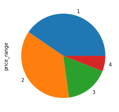

```python
df.price_range.value_counts().plot(kind= 'pie')
```

**10. Variable 'highlights'**

```python
df.highlights
```

```
0         Lunch, Takeaway Available, Credit Card, Dinner...
1         Delivery, No Alcohol Available, Dinner, Takeaw...
2         No Alcohol Available, Dinner, Takeaway Availab...
3         Takeaway Available, Credit Card, Lunch, Delive...
4         Lunch, Serves Alcohol, Cash, Credit Card, Dinn...
                                ...
211939    Dinner, Cash, Lunch, Delivery, Indoor Seating,...
211940    Dinner, Cash, Takeaway Available, Debit Card, ...
211941    Dinner, Cash, Debit Card, Lunch, Takeaway Avai...
211942    Dinner, Delivery, Credit Card, Lunch, Cash, Ta...
211943    Dinner, Cash, Takeaway Available, Debit Card, ...
Name: highlights, Length: 211944, dtype: category
Categories (31454, object): [Air Conditioned, Air Conditioned, Desserts and Bakes, Indoor Se..., Air Conditioned, Desserts and Bakes, Pure Veg, Air Conditioned, Pure Veg, Desserts and Bakes, ..., Takeaway Available, Standing Tables, Cash, Dig..., Takeaway Available, Standing Tables, Cash, Dinner, Ta…
```

- write a small function to know the number of times a facility has appeared in the 'Highlights'.

```python
df_cuisines(df.highlights)
```

```
{'4/5 Star',
 'Above 18 Only',
 'Air Conditioned',
 'Alipay Accepted',
 'All Day Breakfast',
 'Available for Functions',
 'Axis Bank - Dining Delights',
 'BYOB',
 'Beer',
 'Bira 91 Beer',
 'Board Games',
 'Breakfast',
 'Brunch',
 'Buffet',
 'Bulk Orders Accepted',
 'Card Upon Delivery',
 'Cash',
 'Catering Available',
 'Celebrity Frequented',
 'City View',
 'Couple Entry Only',
 'Craft Beer',
 'Credit Card',
 'DJ',
 'Dance Floor',
 'Dark Kitchen',
 'Debit Card',
 'Delivery',
 'Desserts and Bakes',
 'Digital Payments Accepted',
 'Dinner',
 'Disabled Friendly',
 'Drive Thru',
 'Drive in',
 'Entry Fee',
 'Free Parking',
 'Free Wifi',
 'Fullbar',
 'Gaming Area',
 'Gastro Pub',
```

[output cut: 49 more lines]

```
 'Table booking for Groups',
 'Table booking not available',
 'Table booking recommended',
 'Table reservation required',
 'Takeaway Available',
 'Ticket Restaurant',
 'Unlimited Pizza',
 'Valet Parking Available',
 'Variable Menu',
 'Vegan Options',
 'Wheelchair Accessible',
 'Wifi',
 'Wine',
 'Wine Tasting',
 'nan'}
```

```python
result_highlights = df_cuisines(df.highlights)
store_highlights=[]
data_highlights=pd.DataFrame(result_highlights,columns=['Facility'])
for i in result_highlights:
    store_highlights.append(df['highlights'].str.count(i).sum())
data_highlights
data_highlights['frequency']=store_highlights
data_highlights
```

|  | Facility | frequency |
| --- | --- | --- |
| 0 | DJ | 4609.0 |
| 1 | Ticket Restaurant | 531.0 |
| 2 | Subscription Available | 3.0 |
| 3 | Table booking for Groups | 1359.0 |
| 4 | Indoor Seating | 175396.0 |
| ... | ... | ... |
| 99 | Wheelchair Accessible | 8857.0 |
| 100 | Buffet | 7733.0 |
| 101 | Gaming Area | 241.0 |
| 102 | Romantic Dining | 712.0 |
| 103 | Axis Bank - Dining Delights | 5550.0 |

104 rows × 2 columns

- Now we find out which facility occurs most number of in the data.

```python
save_df=data_highlights.sort_values(by=['frequency'],ascending=False).head(1)
save_df
```

|  | Facility | frequency |
| --- | --- | --- |
| 83 | Cash | 203036.0 |

**11. Variable 'aggregate_rating'**

```python
df.aggregate_rating
```

```
0         4.4
1         4.4
2         4.2
3         4.3
4         4.9
         ...
211939    4.1
211940    4.1
211941    4.0
211942    3.7
211943    4.0
Name: aggregate_rating, Length: 211944, dtype: float64
```

**12. Variable 'rating_text'**

```python
df.rating_text
```

```
0         Very Good
1         Very Good
2         Very Good
3         Very Good
4         Excellent
            ...
211939    Very Good
211940    Very Good
211941    Very Good
211942         Good
211943    Very Good
Name: rating_text, Length: 211944, dtype: category
Categories (39, object): [Average, Baik, Bardzo dobrze, Biasa, ..., Wybitnie, Çok iyi, İyi, Średnio]
```

Creating a New feature for better understanding of ratings

```python
df.rating_text.unique()

df.loc[((df.aggregate_rating>=0) & (df.aggregate_rating<=1)),'rating_text_new']='Poor'
df.loc[((df.aggregate_rating>=1) & (df.aggregate_rating<=2)),'rating_text_new']='Average'
df.loc[((df.aggregate_rating>=2) & (df.aggregate_rating<=3)),'rating_text_new']='Good'
df.loc[((df.aggregate_rating>=3) & (df.aggregate_rating<=4)),'rating_text_new']='Very Good'
df.loc[((df.aggregate_rating>=4) & (df.aggregate_rating<=5)),'rating_text_new']='Excellent'
df['rating_text_new'].unique()
```

```
array(['Excellent', 'Very Good', 'Poor', 'Good', 'Average'], dtype=object)
```

**13. Variable 'votes'**

```python
df.votes
```

```
0          814
1         1203
2          801
3          693
4          470
          ...
211939     243
211940     187
211941     111
211942     128
211943      93
Name: votes, Length: 211944, dtype: int64
```

**14. Variable 'photo_count'**

```python
df.photo_count
```

```
0         154
1         161
2         107
3         157
4         291
         ...
211939     40
211940     40
211941     38
211942     34
211943     53
Name: photo_count, Length: 211944, dtype: int64
```

**15. Variable 'delivery'**

```python
df.delivery
```

```
0        -1
1        -1
2         1
3         1
4         1
         ..
211939   -1
211940    1
211941   -1
211942    1
211943    1
Name: delivery, Length: 211944, dtype: category
Categories (3, int64): [-1, 0, 1]
```

## 6. Check for missing values

```python
df.isnull().sum()
```

```
res_id                       0
name                         0
establishment             4827
url                          0
address                    134
city                         0
city_id                      0
locality                     0
latitude                  1339
longitude                 1329
zipcode                 163187
cuisines                  1391
timings                   3874
average_cost_for_two         0
price_range                  0
highlights                2069
aggregate_rating             0
rating_text                  0
votes                        0
photo_count                  0
delivery                     0
takeaway                     0
rating_text_new              0
dtype: int64
```

**6. Study summary statistics**

Let us check the summary statistics for numerical variables.

```python
df.describe()
```

|  | latitude | longitude | average_cost_for_two | aggregate_rating | votes | photo_count |
| --- | --- | --- | --- | --- | --- | --- |
| count | 210605.000000 | 210615.000000 | 211944.000000 | 211944.000000 | 211944.000000 | 211944.000000 |
| mean | 21.586832 | 78.104827 | 595.812229 | 3.395937 | 378.002571 | 256.971224 |
| std | 6.823595 | 4.286852 | 606.239363 | 1.283642 | 925.333106 | 867.668940 |
| min | 8.400144 | 69.014446 | 0.000000 | 0.000000 | 0.000000 | 0.000000 |
| 25% | 15.545368 | 74.892431 | 250.000000 | 3.300000 | 16.000000 | 3.000000 |
| 50% | 22.541707 | 77.434536 | 400.000000 | 3.800000 | 100.000000 | 18.000000 |
| 75% | 26.847055 | 80.221799 | 700.000000 | 4.100000 | 362.000000 | 128.000000 |
| max | 34.214702 | 91.832769 | 30000.000000 | 4.900000 | 42539.000000 | 17702.000000 |

## 7. Study correlation

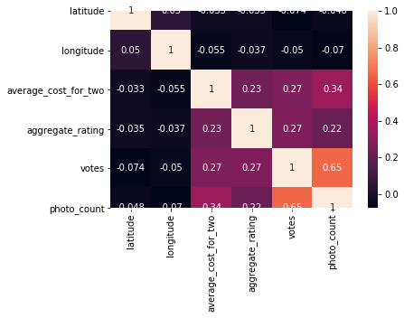

```python
import seaborn as sns
corr=df.corr()
sns.heatmap(corr,annot=True)
```

## 8. Detect outliers

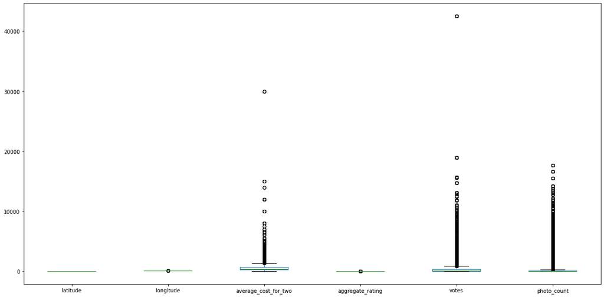

```python
df.plot(kind='box',figsize=(20,10))
```

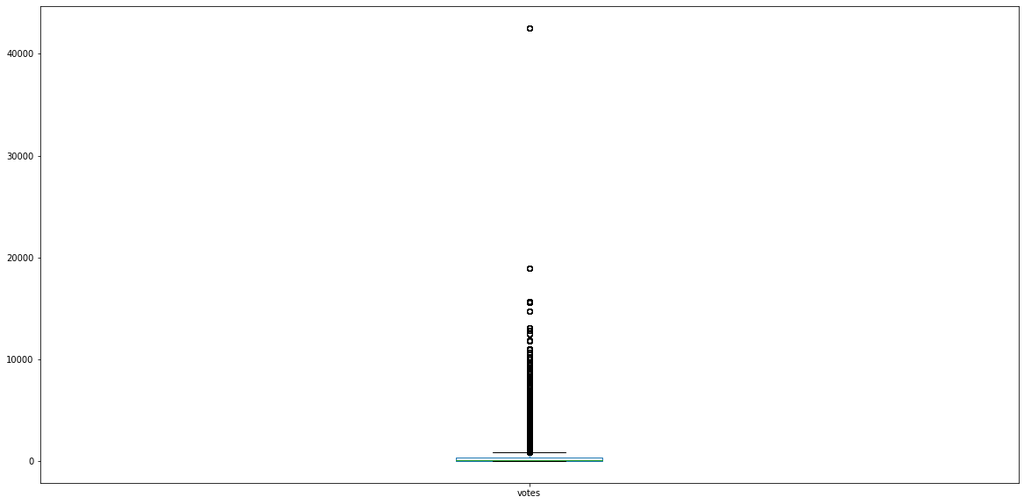

```python
df['votes'].plot(kind='box',figsize=(20,10))
```

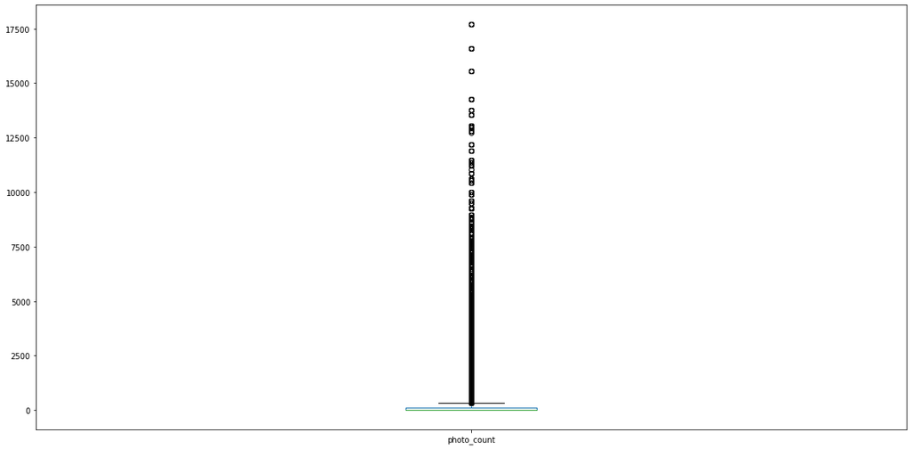

```python
df['photo_count'].plot(kind='box',figsize=(20,10))
```

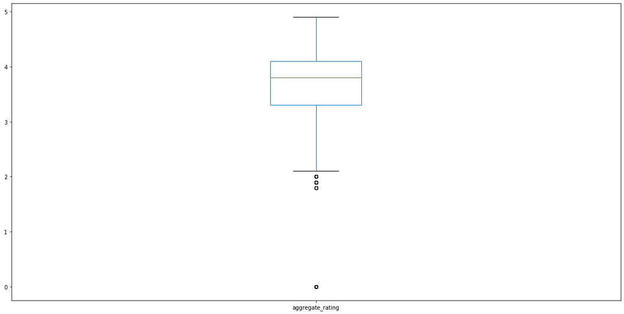

```python
df['aggregate_rating'].plot(kind='box',figsize=(20,10))
```

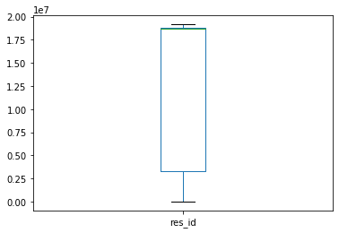

```python
df.res_id=df.res_id.astype('int64')
df['res_id'].plot(kind='box')
```

## 9. Create a new variable 'region'

```python
df_cuisines(df.city)
```

```
{'Agra',
 'Ahmedabad',
 'Ajmer',
 'Alappuzha',
 'Allahabad',
 'Amravati',
 'Amritsar',
 'Aurangabad',
 'Bangalore',
 'Bhopal',
 'Bhubaneshwar',
 'Chandigarh',
 'Chennai',
 'Coimbatore',
 'Cuttack',
 'Darjeeling',
 'Dehradun',
 'Dharamshala',
 'Faridabad',
 'Gandhinagar',
 'Gangtok',
 'Ghaziabad',
 'Goa',
 'Gorakhpur',
 'Greater Noida',
 'Guntur',
 'Gurgaon',
 'Guwahati',
 'Gwalior',
 'Haridwar',
 'Howrah',
 'Hyderabad',
 'Indore',
 'Jabalpur',
 'Jaipur',
 'Jalandhar',
 'Jammu',
 'Jamnagar',
 'Jamshedpur',
 'Jhansi',
```

[output cut: 43 more lines]

```
 'Srinagar',
 'Surat',
 'Thane',
 'Thrissur',
 'Tirupati',
 'Trichy',
 'Trivandrum',
 'Udaipur',
 'Udupi',
 'Vadodara',
 'Varanasi',
 'Vellore',
 'Vijayawada',
 'Vizag',
 'Zirakpur'}
```

```python
dict_region={'Agra':"north", 'Ahmedabad':'west', 'Ajmer':'west', 'Alappuzha':'south', 'Allahabad':'north', 'Amravati':"west",
       'Amritsar':'north', 'Aurangabad':'west', 'Bangalore':'south', 'Bhopal':'west', 'Bhubaneshwar':'east',
       'Chandigarh':'north', 'Chennai':'south', 'Coimbatore':'south', 'Cuttack':'east', 'Darjeeling':'east',
       'Dehradun':'north', 'Dharamshala':'north', 'Faridabad':"north", 'Gandhinagar':"west", 'Gangtok':'east',
       'Ghaziabad':"north", 'Goa':"west", 'Gorakhpur':"north", 'Greater Noida':"north", 'Guntur':"south",
       'Gurgaon':"north", 'Guwahati':"east", 'Gwalior':"east", 'Haridwar':"north", 'Howrah':"east",
       'Hyderabad':"south", 'Indore':"west", 'Jabalpur':"west", 'Jaipur':"west", 'Jalandhar':"north", 'Jammu':"north",
       'Jamnagar':"west", 'Jamshedpur':"east", 'Jhansi':"north", 'Jodhpur':"west", 'Junagadh':"west",
       'Kanpur':"north", 'Kharagpur':"east", 'Kochi':"south", 'Kolhapur':"west", 'Kolkata':"east", 'Kota':"west",
       'Lucknow':"north", 'Ludhiana':"north", 'Madurai':"south", 'Manali':"north", 'Mangalore':"south", 'Manipal':"south",
       'Meerut':"north", 'Mohali':"north", 'Mumbai':"west", 'Mussoorie':"north", 'Mysore':"south", 'Nagpur':"west",
       'Nainital':"north", 'Nashik':"west", 'Navi Mumbai':"west", 'Nayagaon':"north", 'Neemrana':"west",
       'New Delhi':"north", 'Noida':"north", 'Ooty':"south", 'Palakkad':"south", 'Panchkula':"north", 'Patiala':"north",
       'Patna':"north", 'Puducherry':"south", 'Pune':"west", 'Pushkar':"west", 'Raipur':"west", 'Rajkot':"west",
       'Ranchi':"east", 'Rishikesh':"north", 'Salem':"south", 'Secunderabad':"south", 'Shimla':"north",
       'Siliguri':"east", 'Srinagar':"north", 'Surat':"west", 'Thane':"west", 'Thrissur':"south", 'Tirupati':"south",
       'Trichy':'south', 'Trivandrum':'south', 'Udaipur':'west', 'Udupi':"south", 'Vadodara':"west", 'Varanasi':"north",
       'Vellore':"south", 'Vijayawada':"south", 'Vizag':"south", 'Zirakpur':"north"}
```

```python
df.drop(df[df.city=='north'].index,inplace=True)
save_region=[]
for i in df.city:
    save_region.append(dict_region[i])

df['region']=save_region
df
```

|  | res_id | name | establishment | url | address | city | city_id | locality | latitude | longitude | ... | price_range | highlights | aggregate_rating | rating_text | votes | photo_count | delivery | takeaway | rating_text_new | region |
| --- | --- | --- | --- | --- | --- | --- | --- | --- | --- | --- | --- | --- | --- | --- | --- | --- | --- | --- | --- | --- | --- |
| 0 | 3400299 | Bikanervala | Quick Bites | https://www.zomato.com/agra/bikanervala-khanda... | Kalyani Point, Near Tulsi Cinema, Bypass Road,... | Agra | 34 | Khandari | 27.211450 | 78.002381 | ... | 2 | Lunch, Takeaway Available, Credit Card, Dinner... | 4.4 | Very Good | 814 | 154 | -1 | -1 | Excellent | north |
| 1 | 3400005 | Mama Chicken Mama Franky House | Quick Bites | https://www.zomato.com/agra/mama-chicken-mama-... | Main Market, Sadar Bazaar, Agra Cantt, Agra | Agra | 34 | Agra Cantt | 27.160569 | 78.011583 | ... | 2 | Delivery, No Alcohol Available, Dinner, Takeaw... | 4.4 | Very Good | 1203 | 161 | -1 | -1 | Excellent | north |
| 2 | 3401013 | Bhagat Halwai | Quick Bites | https://www.zomato.com/agra/bhagat-halwai-2-sh... | 62/1, Near Easy Day, West Shivaji Nagar, Goalp... | Agra | 34 | Shahganj | 27.182938 | 77.979684 | ... | 1 | No Alcohol Available, Dinner, Takeaway Availab... | 4.2 | Very Good | 801 | 107 | 1 | -1 | Excellent | north |
| 3 | 3400290 | Bhagat Halwai | Quick Bites | https://www.zomato.com/agra/bhagat-halwai-civi... | Near Anjana Cinema, Nehru Nagar, Civil Lines, ... | Agra | 34 | Civil Lines | 27.205668 | 78.004799 | ... | 1 | Takeaway Available, Credit Card, Lunch, Delive... | 4.3 | Very Good | 693 | 157 | 1 | -1 | Excellent | north |
| 4 | 3401744 | The Salt Cafe Kitchen & Bar | Casual Dining | https://www.zomato.com/agra/the-salt-cafe-kitc... | 1C,3rd Floor, Fatehabad Road, Tajganj, Agra | Agra | 34 | Tajganj | 27.157709 | 78.052421 | ... | 3 | Lunch, Serves Alcohol, Cash, Credit Card, Dinn... | 4.9 | Excellent | 470 | 291 | 1 | -1 | Excellent | north |
| ... | ... | ... | ... | ... | ... | ... | ... | ... | ... | ... | ... | ... | ... | ... | ... | ... | ... | ... | ... | ... | ... |
| 211939 | 3202251 | Kali Mirch Cafe And Restaurant | Casual Dining | https://www.zomato.com/vadodara/kali-mirch-caf... | Manu Smriti Complex, Near Navrachna School, GI... | Vadodara | 32 | Fatehgunj | 22.336931 | 73.192356 | ... | 2 | Dinner, Cash, Lunch, Delivery, Indoor Seating,... | 4.1 | Very Good | 243 | 40 | -1 | -1 | Excellent | west |
| 211940 | 3200996 | Raju Omlet | Quick Bites | https://www.zomato.com/vadodara/raju-omlet-kar... | Mahalaxmi Apartment, Opposite B O B, Karoli Ba... | Vadodara | 32 | Karelibaug | 22.322455 | 73.197203 | ... | 1 | Dinner, Cash, Takeaway Available, Debit Card, ... | 4.1 | Very Good | 187 | 40 | 1 | -1 | Excellent | west |
| 211941 | 18984164 | The Grand Thakar | Casual Dining | https://www.zomato.com/vadodara/the-grand-thak... | 3rd Floor, Shreem Shalini Mall, Opposite Conqu... | Vadodara | 32 | Alkapuri | 22.310563 | 73.171164 | ... | 2 | Dinner, Cash, Debit Card, Lunch, Takeaway Avai... | 4.0 | Very Good | 111 | 38 | -1 | -1 | Excellent | west |
| 211942 | 3201138 | Subway | Quick Bites | https://www.zomato.com/vadodara/subway-1-akota... | G-2, Vedant Platina, Near Cosmos, Akota, Vadodara | Vadodara | 32 | Akota | 22.270027 | 73.143068 | ... | 2 | Dinner, Delivery, Credit Card, Lunch, Cash, Ta... | 3.7 | Good | 128 | 34 | 1 | -1 | Very Good | west |
| 211943 | 18879846 | Freshcos - The Health Cafe | Café | https://www.zomato.com/vadodara/freshcos-the-h... | Shop 7, Ground Floor, Opposite Natubhai Circle... | Vadodara | 32 | Vadiwadi | 22.309935 | 73.158768 | ... | 2 | Dinner, Cash, Takeaway Available, Debit Card, ... | 4.0 | Very Good | 93 | 53 | 1 | -1 | Excellent | west |

211944 rows × 24 columns

```python
city_data=df.groupby('region')['city'].unique()
city_data
```

```
region
east     [Bhubaneshwar, Cuttack, Darjeeling, Gangtok, G...
north    [Agra, Allahabad, Amritsar, Chandigarh, Mohali...
south    [Alappuzha, Bangalore, Chennai, Coimbatore, Gu...
west     [Ahmedabad, Gandhinagar, Ajmer, Amravati, Aura...
Name: city, dtype: object
```

## 10. Some more Analysis

### 1. To find which cities have expensive restaurants

- plot the cities which have costliest restaurants.

```python
df[['name','average_cost_for_two','city','price_range']].head()
```

|  | name | average_cost_for_two | city | price_range |
| --- | --- | --- | --- | --- |
| 0 | Bikanervala | 700 | Agra | 2 |
| 1 | Mama Chicken Mama Franky House | 600 | Agra | 2 |
| 2 | Bhagat Halwai | 300 | Agra | 1 |
| 3 | Bhagat Halwai | 300 | Agra | 1 |
| 4 | The Salt Cafe Kitchen & Bar | 1000 | Agra | 3 |

```python
save_costly=df[['city','average_cost_for_two']].groupby(['city']).mean()

values_for_graph=save_costly.sort_values(by=['average_cost_for_two'],ascending=False).head(5)

values_for_graph['city']=values_for_graph.index

values_for_graph
```

| city | average_cost_for_two | city |
| --- | --- | --- |
| Mumbai | 1388.994921 | Mumbai |
| New Delhi | 1379.698826 | New Delhi |
| Gurgaon | 1333.906977 | Gurgaon |
| Bangalore | 1036.187890 | Bangalore |
| Pune | 979.858904 | Pune |

```python
save_costly=df[['city','average_cost_for_two']].groupby(['city']).mean()
values_for_graph=save_costly.sort_values(by=['average_cost_for_two'],ascending=False).head(5)
values_for_graph
```

| city | average_cost_for_two |
| --- | --- |
| Mumbai | 1388.994921 |
| New Delhi | 1379.698826 |
| Gurgaon | 1333.906977 |
| Bangalore | 1036.187890 |
| Pune | 979.858904 |

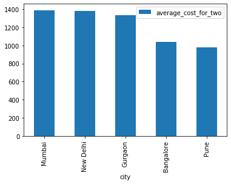

```python
values_for_graph.plot(kind='bar')
```

### 2. Comparing regions

### 2a. Highlights available in restaurants for different regions

To cater our analysis we define the regions as nothern, eastern, western and southern.

We first need to select the unique facilities available in each region and sort according to their frequencies.

**Highlights of the northern region**

```python
data_high_north=(df[['highlights']][df.region=='north'])
ans_north=(df_cuisines(data_high_north.highlights))
store_inter_north=[]

df_highlights_north=pd.DataFrame(ans_north,columns=['Facility'])

for i in ans_north:
    store_inter_north.append(data_high_north['highlights'].str.count(i).sum())

df_highlights_north['Frequency']=store_inter_north
df_highlights_north.sort_values(by=['Frequency'],ascending=False)
```

|  | Facility | Frequency |
| --- | --- | --- |
| 78 | Cash | 58515.0 |
| 46 | Takeaway Available | 53133.0 |
| 3 | Indoor Seating | 50291.0 |
| 58 | Dinner | 50027.0 |
| 18 | Lunch | 49720.0 |
| ... | ... | ... |
| 83 | Wine Tasting | 6.0 |
| 41 | Unlimited Pizza | 5.0 |
| 89 | Couple Entry Only | 3.0 |
| 44 | Members Only | 2.0 |
| 12 | nan | 0.0 |

96 rows × 2 columns

**Highlights of the eastern region**

```python
data_high_east=(df[['highlights']][df.region=='east'])
ans_east=(df_cuisines(data_high_east.highlights))
store_inter_east=[]

df_highlights_east=pd.DataFrame(ans_east,columns=['Facility'])

for i in ans_east:
    store_inter_east.append(data_high_east['highlights'].str.count(i).sum())

df_highlights_east['Frequency']=store_inter_east
df_highlights_east.sort_values(by=['Frequency'],ascending=False)
```

|  | Facility | Frequency |
| --- | --- | --- |
| 76 | Cash | 22216.0 |
| 44 | Takeaway Available | 19738.0 |
| 3 | Indoor Seating | 18827.0 |
| 56 | Dinner | 17892.0 |
| 18 | Lunch | 17661.0 |
| ... | ... | ... |
| 77 | Entry Fee | 8.0 |
| 38 | Seaside | 5.0 |
| 14 | Dark Kitchen | 3.0 |
| 42 | Gin Bar | 3.0 |
| 12 | nan | 0.0 |

94 rows × 2 columns

**Highlights of the southern region**

```python
data_high_south=(df[['highlights']][df.region=='south'])
ans_south=(df_cuisines(data_high_south.highlights))
store_inter_south=[]

df_highlights_south=pd.DataFrame(ans_south,columns=['Facility'])

for i in ans_south:
    store_inter_south.append(data_high_south['highlights'].str.count(i).sum())

df_highlights_south['Frequency']=store_inter_south
df_highlights_south.sort_values(by=['Frequency'],ascending=False)
```

|  | Facility | Frequency |
| --- | --- | --- |
| 79 | Cash | 57267.0 |
| 3 | Indoor Seating | 52273.0 |
| 47 | Takeaway Available | 51346.0 |
| 59 | Dinner | 48379.0 |
| 18 | Lunch | 47381.0 |
| ... | ... | ... |
| 91 | Couple Entry Only | 7.0 |
| 70 | Celebrity Frequented | 3.0 |
| 45 | Members Only | 2.0 |
| 14 | Dark Kitchen | 1.0 |
| 12 | nan | 0.0 |

99 rows × 2 columns

**Highlights of the western region**

```python
data_high_west=(df[['highlights']][df.region=='west'])
ans_west=(df_cuisines(data_high_west.highlights))
store_inter_west=[]

df_highlights_west=pd.DataFrame(ans_west,columns=['Facility'])

for i in ans_west:
    store_inter_west.append(data_high_west['highlights'].str.count(i).sum())

df_highlights_west['Frequency']=store_inter_west
df_highlights_west.sort_values(by=['Frequency'],ascending=False)
```

|  | Facility | Frequency |
| --- | --- | --- |
| 81 | Cash | 65038.0 |
| 48 | Takeaway Available | 56725.0 |
| 4 | Indoor Seating | 54005.0 |
| 61 | Dinner | 52993.0 |
| 19 | Lunch | 50783.0 |
| ... | ... | ... |
| 27 | Subscription Required | 3.0 |
| 2 | Subscription Available | 3.0 |
| 60 | Bira 91 Beer | 2.0 |
| 15 | Dark Kitchen | 1.0 |
| 13 | nan | 0.0 |

101 rows × 2 columns

#### Plot the barplot for different regions

We shall now plot the graphs for top 10 highlights.

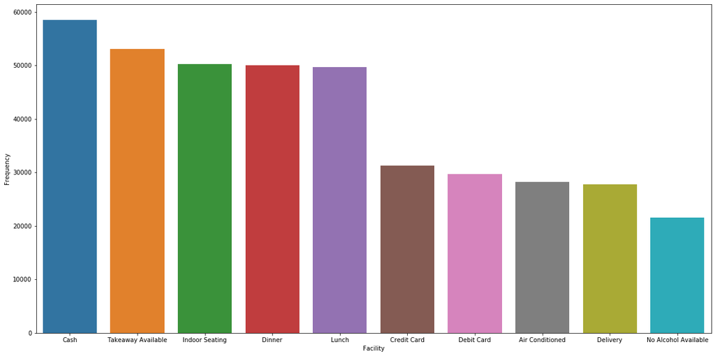

```python
import seaborn as sns
import matplotlib.pyplot as plt
save_north=df_highlights_north.sort_values(by=['Frequency'],ascending=False).head(10)
fig_dims = (20,10)
fig, ax = plt.subplots(figsize=fig_dims)
sns.barplot(x='Facility',y='Frequency',ax=ax,data=save_north)
```

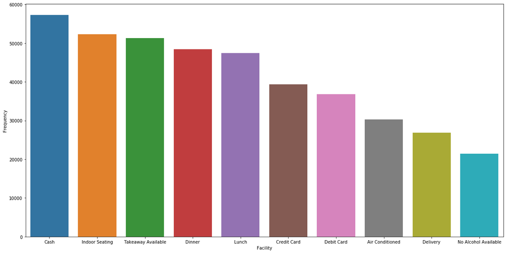

```python
import seaborn as sns
import matplotlib.pyplot as plt
save_south=df_highlights_south.sort_values(by=['Frequency'],ascending=False).head(10)
fig_dims = (20,10)
fig, ax = plt.subplots(figsize=fig_dims)
sns.barplot(x='Facility',y='Frequency',ax=ax,data=save_south)
```

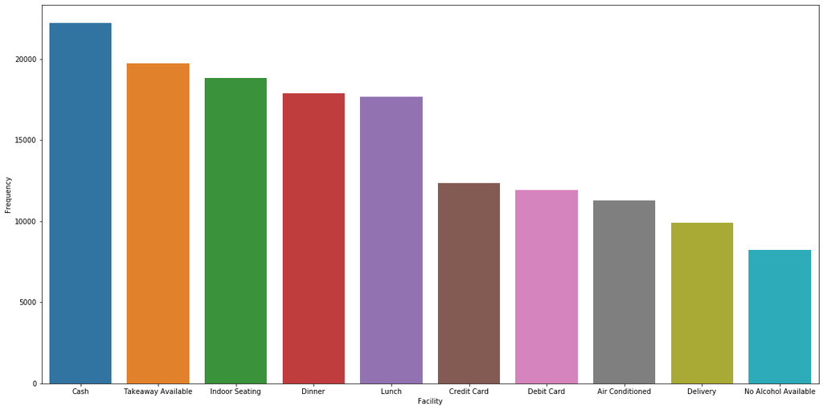

```python
import seaborn as sns
import matplotlib.pyplot as plt
save_east=df_highlights_east.sort_values(by=['Frequency'],ascending=False).head(10)
fig_dims = (20,10)
fig, ax = plt.subplots(figsize=fig_dims)
sns.barplot(x='Facility',y='Frequency',ax=ax,data=save_east)
```

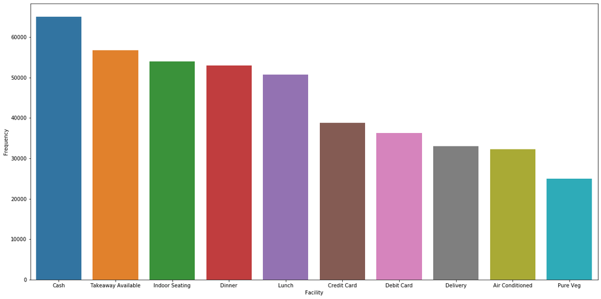

```python
import seaborn as sns
import matplotlib.pyplot as plt
save_west=df_highlights_west.sort_values(by=['Frequency'],ascending=False).head(10)
fig_dims = (20,10)
fig, ax = plt.subplots(figsize=fig_dims)
sns.barplot(x='Facility',y='Frequency',ax=ax,data=save_west)
```

### 2b. Cuisines available in restaurants for different regions

**Cuisines in the northern region**

```python
data_cui_north=(df[['cuisines']][df.region=='north'])
ans_north=(df_cuisines(data_cui_north.cuisines))
store_inter_north=[]

df_cuisines_north=pd.DataFrame(ans_north,columns=['cuisines'])

for i in ans_north:
    store_inter_north.append(data_cui_north['cuisines'].str.count(i).sum())

df_cuisines_north['Frequency']=store_inter_north
df_cuisines_north.sort_values(by=['Frequency'],ascending=False)
```

|  | cuisines | Frequency |
| --- | --- | --- |
| 81 | Indian | 34304.0 |
| 107 | North Indian | 28006.0 |
| 91 | Chinese | 16763.0 |
| 36 | Fast Food | 15757.0 |
| 67 | Continental | 7389.0 |
| ... | ... | ... |
| 64 | South American | 2.0 |
| 20 | Swedish | 1.0 |
| 86 | Cafe Food | 1.0 |
| 83 | Pan Asian | 1.0 |
| 17 | nan | 0.0 |

114 rows × 2 columns

**Cuisines in the eastern region**

```python
data_cui_east=(df[['cuisines']][df.region=='east'])
ans_east=(df_cuisines(data_cui_east.cuisines))
store_inter_east=[]

df_cuisines_east=pd.DataFrame(ans_east,columns=['cuisines'])

for i in ans_east:
    store_inter_east.append(data_cui_east['cuisines'].str.count(i).sum())

df_cuisines_east['Frequency']=store_inter_east
df_cuisines_east.sort_values(by=['Frequency'],ascending=False)
```

|  | cuisines | Frequency |
| --- | --- | --- |
| 70 | Indian | 12113.0 |
| 94 | North Indian | 9579.0 |
| 79 | Chinese | 8892.0 |
| 30 | Fast Food | 4849.0 |
| 76 | Biryani | 3350.0 |
| ... | ... | ... |
| 58 | Fried Chicken | 1.0 |
| 11 | Hot dogs | 1.0 |
| 77 | Bohri | 1.0 |
| 26 | Bubble Tea | 1.0 |
| 12 | nan | 0.0 |

101 rows × 2 columns

**Cuisines in the southern region**

```python
data_cui_south=(df[['cuisines']][df.region=='south'])
ans_south=(df_cuisines(data_cui_south.cuisines))
store_inter_south=[]

df_cuisines_south=pd.DataFrame(ans_south,columns=['cuisines'])

for i in ans_south:
    store_inter_south.append(data_cui_south['cuisines'].str.count(i).sum())

df_cuisines_south['Frequency']=store_inter_south
df_cuisines_south.sort_values(by=['Frequency'],ascending=False)
```

|  | cuisines | Frequency |
| --- | --- | --- |
| 82 | Indian | 37517.0 |
| 105 | North Indian | 20263.0 |
| 17 | South Indian | 16558.0 |
| 91 | Chinese | 15453.0 |
| 89 | Biryani | 9791.0 |
| ... | ... | ... |
| 25 | Mishti | 1.0 |
| 13 | Pakistani | 1.0 |
| 19 | Naga | 1.0 |
| 86 | Odia | 1.0 |
| 16 | nan | 0.0 |

114 rows × 2 columns

**Cuisines in the western region**

```python
data_cui_west=(df[['cuisines']][df.region=='west'])
ans_west=(df_cuisines(data_cui_west.cuisines))
store_inter_west=[]

df_cuisines_west=pd.DataFrame(ans_west,columns=['cuisines'])

for i in ans_west:
    store_inter_west.append(data_cui_west['cuisines'].str.count(i).sum())

df_cuisines_west['Frequency']=store_inter_west
df_cuisines_west.sort_values(by=['Frequency'],ascending=False)
```

|  | cuisines | Frequency |
| --- | --- | --- |
| 80 | Indian | 34780.0 |
| 108 | North Indian | 28117.0 |
| 34 | Fast Food | 18822.0 |
| 92 | Chinese | 16881.0 |
| 53 | Beverages | 8538.0 |
| ... | ... | ... |
| 90 | Bohri | 2.0 |
| 85 | Cafe Food | 2.0 |
| 25 | Mandi | 1.0 |
| 71 | Assamese | 1.0 |
| 14 | nan | 0.0 |

116 rows × 2 columns

- Plot the barplot for top 10 cuisines served in the four regions

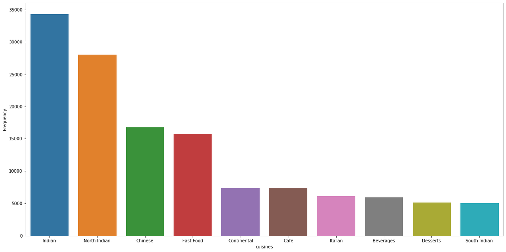

```python
import seaborn as sns
import matplotlib.pyplot as plt
fig_dms=(20,10)
fig, ax=plt.subplots(figsize=fig_dms)
north_cui=df_cuisines_north.sort_values(by=['Frequency'],ascending=False).head(10)
sns.barplot(x='cuisines',y='Frequency',ax=ax,data=north_cui)
```

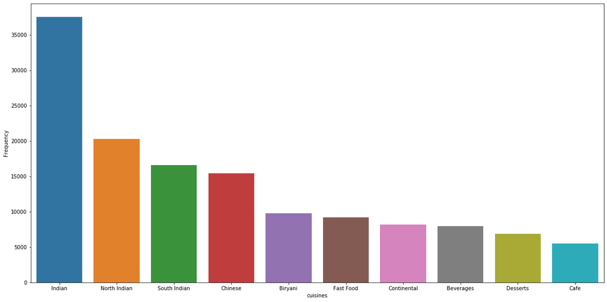

```python
import seaborn as sns
import matplotlib.pyplot as plt
fig_dms=(20,10)
fig, ax=plt.subplots(figsize=fig_dms)
south_cui=df_cuisines_south.sort_values(by=['Frequency'],ascending=False).head(10)
sns.barplot(x='cuisines',y='Frequency',ax=ax,data=south_cui)
```

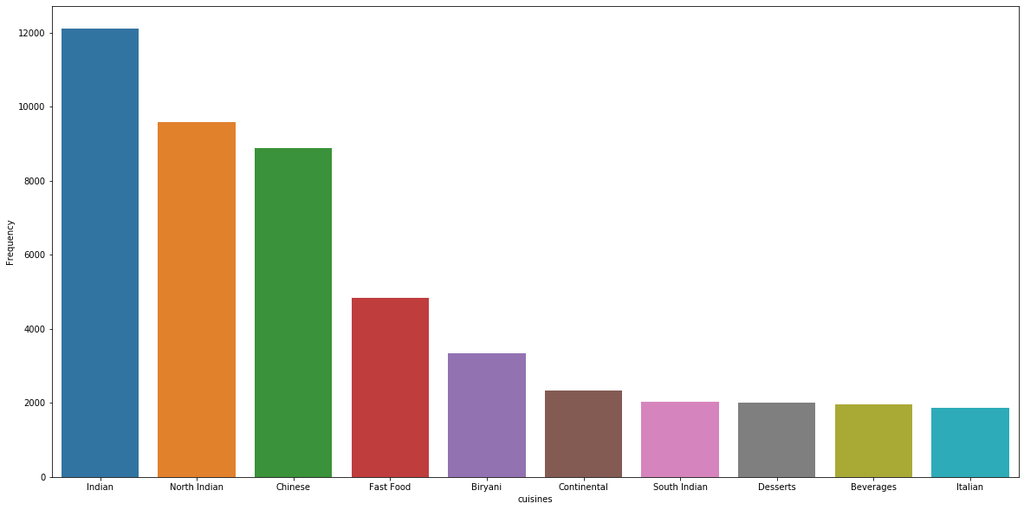

```python
import seaborn as sns
import matplotlib.pyplot as plt
fig_dms=(20,10)
fig, ax=plt.subplots(figsize=fig_dms)
east_cui=df_cuisines_east.sort_values(by=['Frequency'],ascending=False).head(10)
sns.barplot(x='cuisines',y='Frequency',ax=ax,data=east_cui)
```

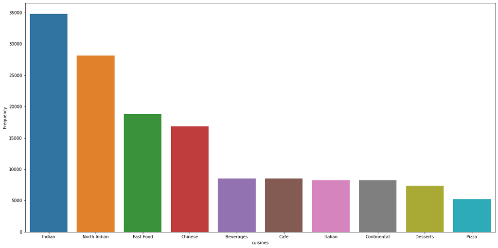

```python
import seaborn as sns
import matplotlib.pyplot as plt
fig_dms=(20,10)
fig, ax=plt.subplots(figsize=fig_dms)
west_cui=df_cuisines_west.sort_values(by=['Frequency'],ascending=False).head(10)
sns.barplot(x='cuisines',y='Frequency',ax=ax,data=west_cui)
```

### 3. The Northern Region

**Now we shall consider only the northern region**

**1. The top 10 cuisines served in Restaurants**

```python
df_cuisines_north.sort_values(by=['Frequency'],ascending=False).head(10)
```

|  | cuisines | Frequency |
| --- | --- | --- |
| 81 | Indian | 34304.0 |
| 107 | North Indian | 28006.0 |
| 91 | Chinese | 16763.0 |
| 36 | Fast Food | 15757.0 |
| 67 | Continental | 7389.0 |
| 98 | Cafe | 7319.0 |
| 87 | Italian | 6167.0 |
| 56 | Beverages | 5927.0 |
| 75 | Desserts | 5183.0 |
| 19 | South Indian | 5093.0 |

**2. Do restaurants with more photo counts and votes have better rating?**

```python
df.aggregate_rating=df.aggregate_rating.astype('float64')
data_north=df[df.region=='north']
data_north.head(10)
data_north[['aggregate_rating','photo_count','votes','rating_text']].sort_values(by=['photo_count','votes'],ascending=False).head(50)
```

|  | aggregate_rating | photo_count | votes | rating_text |
| --- | --- | --- | --- | --- |
| 53925 | 4.2 | 17702 | 4899 | Very Good |
| 54008 | 4.2 | 17702 | 4899 | Very Good |
| 55439 | 4.2 | 17702 | 4899 | Very Good |
| 57876 | 4.2 | 17702 | 4899 | Very Good |
| 58352 | 4.2 | 17702 | 4899 | Very Good |
| 58616 | 4.2 | 17702 | 4899 | Very Good |
| 59156 | 4.2 | 17702 | 4899 | Very Good |
| 59632 | 4.2 | 17702 | 4899 | Very Good |
| 54209 | 4.7 | 15545 | 3322 | Excellent |
| 54796 | 4.7 | 15545 | 3322 | Excellent |
| 56008 | 4.7 | 15545 | 3322 | Excellent |
| 58166 | 4.7 | 15545 | 3322 | Excellent |
| 58553 | 4.7 | 15545 | 3322 | Excellent |
| 58806 | 4.7 | 15545 | 3322 | Excellent |
| 59093 | 4.7 | 15545 | 3322 | Excellent |
| 59446 | 4.7 | 15545 | 3322 | Excellent |
| 59833 | 4.7 | 15545 | 3322 | Excellent |
| 53891 | 4.8 | 11914 | 14751 | Excellent |
| 53988 | 4.8 | 11914 | 14751 | Excellent |
| 55246 | 4.8 | 11914 | 14751 | Excellent |
| 55968 | 4.8 | 11914 | 14751 | Excellent |
| 56065 | 4.8 | 11914 | 14751 | Excellent |
| 56108 | 4.8 | 11914 | 14751 | Excellent |
| 56919 | 4.8 | 11914 | 14751 | Excellent |
| 57598 | 4.8 | 11914 | 14751 | Excellent |
| 57835 | 4.8 | 11914 | 14751 | Excellent |
| 58138 | 4.8 | 11914 | 14751 | Excellent |
| 58332 | 4.8 | 11914 | 14751 | Excellent |
| 58575 | 4.8 | 11914 | 14751 | Excellent |
| 58778 | 4.8 | 11914 | 14751 | Excellent |
| 59115 | 4.8 | 11914 | 14751 | Excellent |
| 59418 | 4.8 | 11914 | 14751 | Excellent |
| 59612 | 4.8 | 11914 | 14751 | Excellent |
| 53916 | 4.6 | 11271 | 4598 | Excellent |
| 54000 | 4.6 | 11271 | 4598 | Excellent |
| 55976 | 4.6 | 11271 | 4598 | Excellent |
| 57358 | 4.6 | 11271 | 4598 | Excellent |
| 57599 | 4.6 | 11271 | 4598 | Excellent |
| 57861 | 4.6 | 11271 | 4598 | Excellent |
| 58194 | 4.6 | 11271 | 4598 | Excellent |
| 58345 | 4.6 | 11271 | 4598 | Excellent |
| 58601 | 4.6 | 11271 | 4598 | Excellent |
| 58834 | 4.6 | 11271 | 4598 | Excellent |
| 59141 | 4.6 | 11271 | 4598 | Excellent |
| 59474 | 4.6 | 11271 | 4598 | Excellent |
| 59625 | 4.6 | 11271 | 4598 | Excellent |
| 54833 | 4.2 | 11046 | 3172 | Very Good |
| 56443 | 4.2 | 11046 | 3172 | Very Good |
| 54077 | 4.3 | 10618 | 5937 | Very Good |
| 54212 | 4.3 | 10618 | 5937 | Very Good |

- Plot a boxplots for the above table

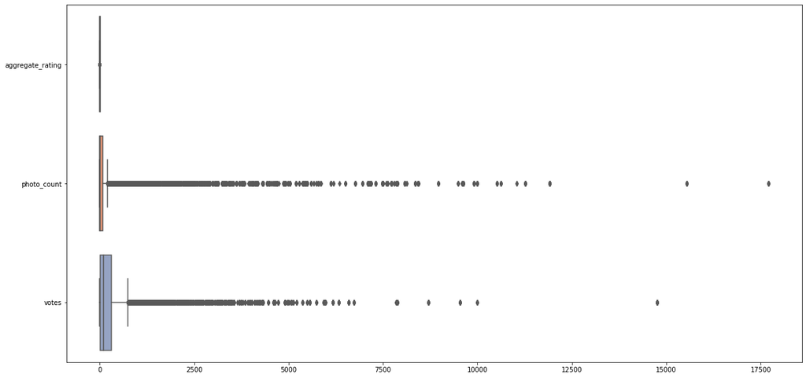

```python
data_box_north=data_north[['aggregate_rating','photo_count','votes']]
fig_dms=(20,10)
fig, ax=plt.subplots(figsize=fig_dms)
sns.boxplot(data=data_box_north, ax=ax, orient="h", palette="Set2")
```

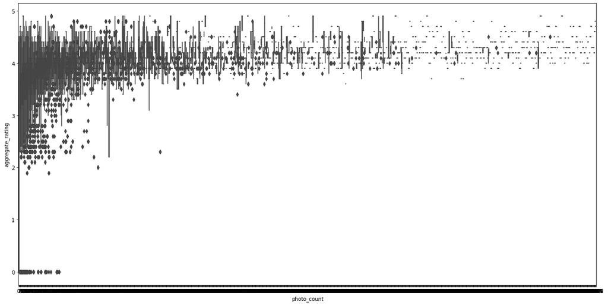

```python
fig_dms=(20,10)
fig, ax=plt.subplots(figsize=fig_dms)
sns.boxplot(x='photo_count',y='aggregate_rating',ax=ax, data=data_box_north)
```

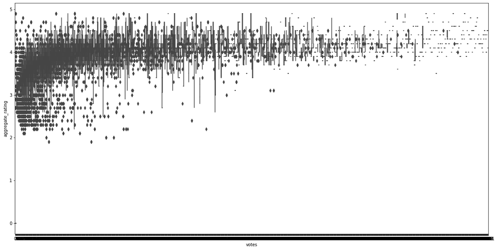

```python
fig_dms=(20,10)
fig, ax=plt.subplots(figsize=fig_dms)
sns.boxplot(x='votes',y='aggregate_rating',ax=ax, data=data_box_north)
```

plotting the various boxplot to understand the relationship between the photo count, votes and their individual influence on the aggregate rating of the restaurant

### 4. The Mumbai city

consider the city mumbai and get a better insights of restuarants in Mumbai.

```python
df_mum=df[df.city=='Mumbai']
df_mum.head()
```

|  | res_id | name | establishment | url | address | city | city_id | locality | latitude | longitude | ... | price_range | highlights | aggregate_rating | rating_text | votes | photo_count | delivery | takeaway | rating_text_new | region |
| --- | --- | --- | --- | --- | --- | --- | --- | --- | --- | --- | --- | --- | --- | --- | --- | --- | --- | --- | --- | --- | --- |
| 134852 | 18562340 | Drinkery 51 | Casual Dining | https://www.zomato.com/mumbai/drinkery-51-band... | 1st Floor, Vibgyor Towers, Bandra Kurla Comple... | Mumbai | 3 | Bandra Kurla Complex | 19.067176 | 72.867493 | ... | 4 | Dinner, Debit Card, Lunch, Serves Alcohol, Cas... | 4.4 | Very Good | 3796 | 1897 | 1 | -1 | Excellent | west |
| 134853 | 34757 | Joeys Pizza | Quick Bites | https://www.zomato.com/mumbai/joeys-pizza-mala... | Shop 1, Plot D, Samruddhi Complex, Chincholi B... | Mumbai | 3 | Malad West | 19.178188 | 72.834666 | ... | 2 | Lunch, Cash, Takeaway Available, Debit Card, D... | 4.5 | Excellent | 7932 | 4960 | -1 | -1 | Excellent | west |
| 134854 | 18548172 | Hitchki | Bar | https://www.zomato.com/mumbai/hitchki-powai?ut... | 5, Transocean, Hiranandani Business Park, Lake... | Mumbai | 3 | Powai | 19.119930 | 72.907331 | ... | 3 | Lunch, Serves Alcohol, Cash, Credit Card, Dinn... | 4.7 | Excellent | 3762 | 12979 | 1 | -1 | Excellent | west |
| 134855 | 18392725 | Tamasha | Lounge | https://www.zomato.com/mumbai/tamasha-lower-pa... | Ground Floor, Victoria House, E.B Marg, Lower ... | Mumbai | 3 | Lower Parel | 19.006060 | 72.827496 | ... | 4 | Dinner, Cash, Takeaway Available, Credit Card,... | 4.7 | Excellent | 4979 | 16595 | -1 | -1 | Excellent | west |
| 134856 | 18962112 | Bayroute | Fine Dining | https://www.zomato.com/mumbai/bayroute-juhu?ut... | 14, Silver Beach Estate, A.B. Nair Road, Oppos... | Mumbai | 3 | Juhu | 19.110684 | 72.825368 | ... | 4 | Dinner, Cash, Takeaway Available, Debit Card, ... | 4.9 | Excellent | 706 | 2484 | -1 | -1 | Excellent | west |

5 rows × 24 columns

**1. Expensive restaurants in Mumbai**

- Define the costliest restaurants whose average cost of two people exceeds Rs.5000 .
- Plot the restaurants which are costliest based on their average cost for two .

```python
df_mum['name'][df_mum.average_cost_for_two>5000].head()
```

```
135881                        Vista - Taj Lands End
135910                  Souk - The Taj Mahal Palace
135918    Wasabi By Morimoto - The Taj Mahal Palace
135924                         Celini - Grand Hyatt
135925          Masala Kraft - The Taj Mahal Palace
Name: name, dtype: category
Categories (40965, object): [# Wednesday, #1, Culinary Avenue - The Red Maple, #788 Avenue, #BC, ..., ट 4 Tasty, द Vege टेबल, स्पेस Bar, ह-tea The Tea Hut]
```

```python
save_ans=df_mum[['name','average_cost_for_two']].sort_values(by=['average_cost_for_two'],ascending=False).drop_duplicates().head(5)
save_ans
```

|  | name | average_cost_for_two |
| --- | --- | --- |
| 136240 | Ocean - The Private Dining Room - Sahara Star | 30000 |
| 138607 | Wasabi By Morimoto - The Taj Mahal Palace | 10000 |
| 140777 | Yuuka - The St. Regis Mumbai | 8000 |
| 138614 | Masala Kraft - The Taj Mahal Palace | 6500 |
| 136744 | Celini - Grand Hyatt | 6000 |

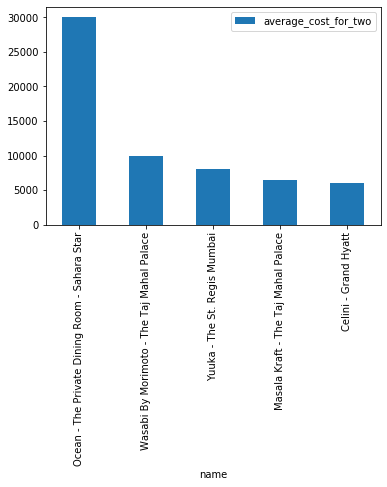

```python
save_ans.plot(kind='bar',x='name',y='average_cost_for_two')
```

**2.To find the top 20 cuisines of Mumbai**

- select unique cuisines available at restaurants in Mumbai
- sort cuisines based on frequency

```python
mumbai_cuisines=df_cuisines(df_mum['cuisines'])
print(mumbai_cuisines)
```

```
{'European', 'German', 'Iranian', 'Vietnamese', 'Kebab', 'Mexican', 'Street Food', 'Greek', 'Hyderabadi', 'Cantonese', 'South Indian', 'Sindhi', 'Mishti', 'Mughlai', 'Salad', 'American', 'Finger Food', 'Paan', 'Asian', 'Bubble Tea', 'Spanish', 'Mediterranean', 'Lucknowi', 'Indonesian', 'Fast Food', …
```

```python
store_cuisine_inter_mum=[]

df_cuisine_mumbai=pd.DataFrame(mumbai_cuisines,columns=['Cuisines_Of_Mumbai'])
for i in mumbai_cuisines:
    store_cuisine_inter_mum.append(df_mum['cuisines'].str.count(i).sum())


df_cuisine_mumbai['frequency']=store_cuisine_inter_mum
df_cuisine_mumbai.sort_values(by=['frequency'],ascending=False).head(20)
```

|  | Cuisines_Of_Mumbai | frequency |
| --- | --- | --- |
| 66 | Indian | 2956 |
| 87 | North Indian | 2444 |
| 74 | Chinese | 1735 |
| 52 | Continental | 1516 |
| 70 | Italian | 1372 |
| 24 | Fast Food | 1271 |
| 59 | Desserts | 1207 |
| 41 | Beverages | 885 |
| 18 | Asian | 814 |
| 15 | American | 656 |
| 79 | Cafe | 552 |
| 0 | European | 529 |
| 5 | Mexican | 497 |
| 13 | Mughlai | 472 |
| 54 | Pizza | 418 |
| 16 | Finger Food | 409 |
| 6 | Street Food | 370 |
| 28 | Bakery | 361 |
| 72 | Biryani | 328 |
| 33 | Seafood | 328 |

**3. To find the popular localities in Mumbai**

```python
df_mum_local=df_mum[['locality']]
df_mum_local['locality'].value_counts().head(5)
```

```
Powai                                297
Andheri Lokhandwala, Andheri West    292
Malad West                           209
Borivali West                        202
Bandra Kurla Complex                 184
Name: locality, dtype: int64
```

**4. Check for relationship between 'aggregate_rating' and 'average_cost_for_two'**

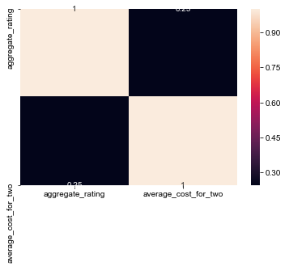

```python
import seaborn as sns
new_corr=df_mum[['aggregate_rating','average_cost_for_two']]
corr_new=new_corr.corr()
sns.heatmap(corr_new,annot=True)
sns.set(rc={'figure.figsize':(11,8)})
```

**5. Multiple box plot for photo_counts based on establishment type.**

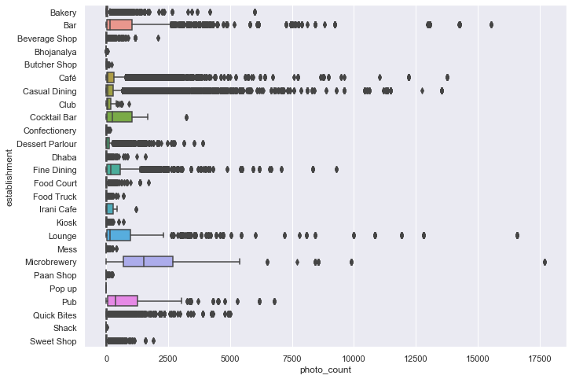

```python
sns.boxplot(x='photo_count',y='establishment',data=df)
sns.set(rc={'figure.figsize':(30,1)})
```

**6. Check for payments method offered in restaurants**

- select unique facilities available at restaurants in western region
- sort facilities based on frequency

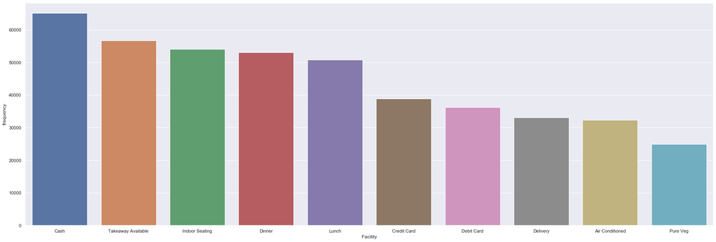

```python
data_high_west=(df[['highlights']][df.region=='west'])
ans_west=(df_cuisines(data_high_west.highlights))
store_inter_west=[]

df_highlights_west=pd.DataFrame(ans_west,columns=['Facility'])
for i in ans_west:
    store_inter_west.append(data_high_west['highlights'].str.count(i).sum())

df_highlights_west['frequency']=store_inter_west
df_highlights_west.sort_values(by=['frequency'],ascending=False)


import seaborn as sns
save_west=df_highlights_west.sort_values(by=['frequency'],ascending=False).head(10)
sns.barplot(x='Facility',y='frequency',data=save_west)
sns.set(rc={'figure.figsize':(30,10)})
```

# Thank You

-Dhairyav Shah